# High Dimensional Data

73-423 Forecasting for Economics and Business

## Outline

- Dimensionality Reduction
- Factor Models
- Dynamic Factor Models
- Nowcasting

## High Dimensional Data

- For most economic and many business forecasting tasks, a lot of *potentially* relevant information is available
  - FRED has over 500,000 economic time series
  - An individual business may have hundreds or thousands of product lines, establishments, workers, etc
- Majority of techniques we have looked at either only use the series whose forecast we are targeting
  - Or add a small set of carefully chosen predictors, chosen based on knowledge of economic or business process
- Can we do better by using more of the data available to us?
  - It seems like the extra information should help: even if only slightly related, forecast should improve
- But handling many predictors also creates big problems for existing methods
  - Adding predictors adds noise, increasing overfitting
  - If many or most predictors don’t help much, adding them could just make predictions worse
  - With as many series as values of outcome, can always get a perfect fit even if all predictors pure nonsense
- Can we find a way to get benefits from the extra information in a reliable way?
  - Today: Some classic approaches
  - Next two classes: Some more modern methods

## Setup

- Goal is to forecast $y_{T+1}$ using available data, including past values $\mathcal{Y}_{T}=\{y_t\}_{t=1}^{T}$
- Also have access to $N$ additional variables each period, $X_t=(x_{1,t},x_{2,t},\ldots,x_{N,t})^{\prime}\in\mathbb{R}^{N}$
  - $X=(X_1^{\prime},X_2^{\prime},\ldots,X_T^{\prime})\in\mathbb{R}^{T\times N}$ collects all the data into an array
- $N$ may be large: comparable to or bigger than $T$
  - Any approach which uses all series in $X_t$ without restrictions to predict $y_{t+h}$ likely to overfit badly
  - This is without even getting into also using past values of $X_t$
- Goal is to come up with forecast procedures $\widehat{f}$ and classes of forecasting rules $\mathcal{F}(X)$ which ensure good performance
  - Balance Risk $R^{*}_p(\mathcal{F})=\underset{f\in\mathcal{F}(X)}{\inf}E_p\ell(y_{T+h},f(X_{T}))$ and overfitting $\frac{1}{T-h}\sum_{t=1}^{T-h}\ell(y_{t+h},\widehat{f}(X_t))-R^{*}_p(\mathcal{F})$
  - Alternately, construct probability model over $(y_t,X_t)$ which provides accurate description of entire system

## Dimensionality Reduction

- The most classical approach to the problem of working with high-dimensional data is **dimensionality reduction**
- Idea: although $N$ large, most information in $X$ can be compressed into a summary which has a much smaller dimension
- Instead of working with $X_t\in\mathbb{R}^{N}$ work with $F_t=(f_{1,t},f_{2,t},\ldots,f_{d,t})\in\mathbb{R}^d$
  - $d$ can be much smaller than $N$
- $F_t$ is calculated from $X$, and replaces it in forecasting procedure
  - Make forecasts using $(\mathcal{Y}_T,F)$, rather than $(\mathcal{Y}_T,X)$
- Choose $F_t$ is a reasonable number of dimensions and contains the relevant info in $X$
  - Preserve information gain from using large set of series
  - Avoid complexity and overfitting from overly complicated models

## Dimensionality Reduction Approaches

- 2 ways of finding a summary $F_t\in\mathbb{R}^d$
- **Unsupervised Dimensionality Reduction**: $F_t$ calculated *only* using information in $X$
  - Reflects some intrinsic structure in the predictors, which are related in a way which makes info beyond summary redundant
- Example: Sample average: $F_t=\frac{1}{N}\sum_{i=1}^{N}x_{i,t}$
  - Use if all series are basically redundant copies of the same information, with differences not relevant
  - E.g., instead of including 6 different measures of money supply, take average of all of them
- **Supervised Dimensionality Reduction**: Use information in $\mathcal{Y}_T$ and $X$ to determine $F_t$
  - $X$ may have a lot going on, but only a bit of that info is related to $y$
- Example: Lasso. Regress $y_{t}$ on $X_{t}$ with L1 penalty on coefficients
  - Sets to 0 many or most coefficients: predictor is combination of only a small subset of columns of $X$
- Both approaches popular and effective in economics
  - Unsupervised case useful when **intrinsic dimension** of $X$ is low: knowing only $F_t$, one could get an accurate guess of $X_t$
    - No point in including full set of predictors since you could recover it from smaller set anyway
  - Supervised case useful when $X$ might not have simple structure, but parts that are related to $y$ do

## Factor Models: Static Case

- Unsupervied approach to get $d$ factors $F_t=\{f_{j,t}\}_{j=1}^{d}$, which predict $\{X_{i,t}\}_{i=1}^{N}$ where $N>>d$
- Want to minimize squared error loss of predictions using some *linear* combination of $d$ factors
- Find coefficients $\Lambda$, called *loadings* and factors $F$ which give best prediction
  - $V(\Lambda,F)=\frac{1}{NT}\sum_{i=1}^{N}\sum_{t=1}^{T}(x_{i,t}-\sum_{j=1}^{d}\lambda_{i,j}f_{j,t})^2$
  - Equivalent to log likelihood in model $X_t=\Lambda F_t+e_t$, $\{e_{i,t}\}_{i=1}^{N}\overset{iid}{\sim}N(0,\sigma_e^2)$
- Trick is that although neither $\Lambda$ nor $F$ is known, we can estimate *both together* by minimizing $V(\Lambda,F)$ jointly
  - $(\widehat{\Lambda},\widehat{F})\in\underset{\Lambda\in\mathbb{R}^{N\times d},F\in\mathbb{R}^{d\times T}}{\arg\min}V(\Lambda,F)$
- Combination of factors and loadings in $d$ dimensions minimizing MSE is not uniquely determined
  - Many possible $F$ and $\Lambda$ could all give exactly the same predictions
  - E.g., divide $f_3$ by 2 and multiply $\lambda_3$ by $2$ and predictions are the same
  - General Case: $(\Lambda R^{-1})(RF)$ for any $d\times d$ *rotation matrix* R defines a valid factor decomposition
- For prediction purposes, we rarely care which factor is which, so long as we are predicting with all of them
  - Can choose an arbitrary minimizer, then *rotate* (pick $R$) to find any others if needed

## Standard Estimator: Principal Components Analysis

- A convenient normalization is to assume loadings $\lambda_j$ are uncorrelated with each other and have norm $1$
  - Typically order them from most to least variance explained
  - Factor estimates found in this way are called **principal components** of $X$
- Factor decomposition with this normalization is called **Principal Components Analysis** or **PCA**
- The principal components are linear combinations of the observations, chosen in such a way that the *largest* possible amount of (remaining) variation in the data is explained by each
- Let $\widehat{\lambda}_1=\underset{\lambda\in\mathbb{R}^{N}:\left\Vert\lambda\right\Vert=1}{\arg\max}\lambda^{\prime}X^\prime X\lambda$: then $\widehat{f}_1=X\widehat{\lambda}_1$ is the first principal component of data $X$
  - $\widehat{f}_1$ is the norm 1 linear combination of $x_{i}$’s with maximum variance
- Each subsequent principal component is defined analogously, except maximizing the proportion explained of the *residual* variance after previous ones have been removed
  - If you have done linear algebra: $\widehat{\lambda}$ are the **eigenvectors** of $X^{\prime}X$, the covariance matrix of data
  - $\widehat{Var}(\widehat{f}_{j})$, the variance which is maximized by the choice, is the corresponding **eigenvalue**
- Principal Components Analysis (PCA) solution mostly useful because easily computed, due to linear algebra connections
- If for interpretation purposes another normalization is preferred, can achieve it by **rotation** of the PCA solution

## Choosing the number of components

- To see how number of factors affects prediction, use graphical measure called a **scree plot**
- It plots the number of factors against the maximum fraction of variance explained by adding one more factor
  - Technical definition for linear algebra fans only: it plots the **eigenvalues** of the covariance matrix, in order
- If model is well described by a few factors, scree plot will flatten off after those factors
- Can also treat problem like model selection, and choose a number using an **information criterion**
- Bai and Ng (2002) suggested $IC^{\text{Bai-Ng}}(d)=IC^{\text{Bai-Ng}}(d)=\ln (V(\widehat{\lambda},\widehat{F})) +dg(N,T)$
  - $g(N,T)$ is some function of N and T, e.g. $\frac{N+T}{NT}\ln(\frac{NT}{N+T})$
- Choosing d to minimize $IC^{\text{Bai-Ng}}(d)$ selects a set of factors which provide good performance without overfitting

```r
library(dplyr) #Data Manipulation
library(ggplot2)

#Load Current FRED-MD Series, as downloaded from https://research.stlouisfed.org/econ/mccracken/fred-databases/
# Described in McCracken and Ng (2014) http://www.columbia.edu/~sn2294/papers/freddata.pdf

#Series of 729 observations of 129 macroeconomic indicators
currentMD<-read.csv("Data/current.csv")
#Drop data column, so result contains only data
fmd<-select(currentMD,-one_of("sasdate"))
#Turn into time series
fredmdts<-ts(fmd,frequency=12,start=c(1959,1))

#Take PCA of Scaled Series
mdPCA<-prcomp(~.,data=fmd,na.action=na.exclude,scale=TRUE)

#Compute statistics
mdPCAinfo<-summary(mdPCA)

#Collect all Group 6 Variables: These are financial series
finseries<-data.frame(currentMD$FEDFUNDS,currentMD$CP3Mx,currentMD$TB3MS,currentMD$TB6MS, currentMD$GS1,currentMD$GS5,currentMD$GS10, currentMD$AAA,currentMD$BAA,currentMD$COMPAPFFx,currentMD$TB3SMFFM,currentMD$TB6SMFFM,
                      currentMD$T1YFFM,currentMD$T5YFFM,currentMD$T10YFFM,currentMD$AAAFFM,
                      currentMD$BAAFFM,currentMD$TWEXMMTH,currentMD$EXSZUSx,
                      currentMD$EXJPUSx,currentMD$EXUSUKx,currentMD$EXCAUSx)

finpca<-prcomp(~.,data=finseries,na.action=na.exclude,scale=TRUE)
```

```r
#Alternate PCA Approaches in R

?prcomp #Default PCA in stats library
?princomp #As above, but with slightly different scaling?

?screeplot #Use to investigate magnitude of components

# Syntax example:

pc.cr <- princomp(USArrests, cor = TRUE)
screeplot(pc.cr)

#Nonlinear dimension reduction tools
library(Rtsne) #Library for t-SNE: 2d representation, for visualization
library(diffusionMap) #Diffusion Maps: nonlinear low dimensional representation from distance matrices (rather than covariance matrices between points) (cf adapreg for) regression on diffusion map components
library(kernlab) #Contains kernel PCA (and spectral clustering)

#To investigate
#install.packages("bayesdfa") #Bayesian dynamic factor models! Great, but want frequentist ones too
#install.packages("nowcasting") #Dynamic factor models for nowcasting!
#install.packages("tsfa") #Time Series factor models
```

## Example: Principal Components Decomposition

- Use FRED-MD (McCracken & Ng 2014) Database of macro indicators available on FRED
  - 129 Macroeconomic series, 728 observations
- Take PCA of (normalized to mean 0 variance 1) series using `prcomp` command (`princomp` also can be used)
- First principal component accounts for 52.552 percent of variability in observations
- First 2 account for 71.938, 3 for 80.721, etc
- Over 99% Accounted for in first 20: can go from 129 data series to 20 dimensions, and lose very little variation in data
  - The vector of principal components can replace the full 129-dimensional observation $x_t$
- Factor *loadings* or *rotations* are vector of weights placed on each of the 129 series to produce each principal component

## 2 Dimensional PCA Approximation of Data Set

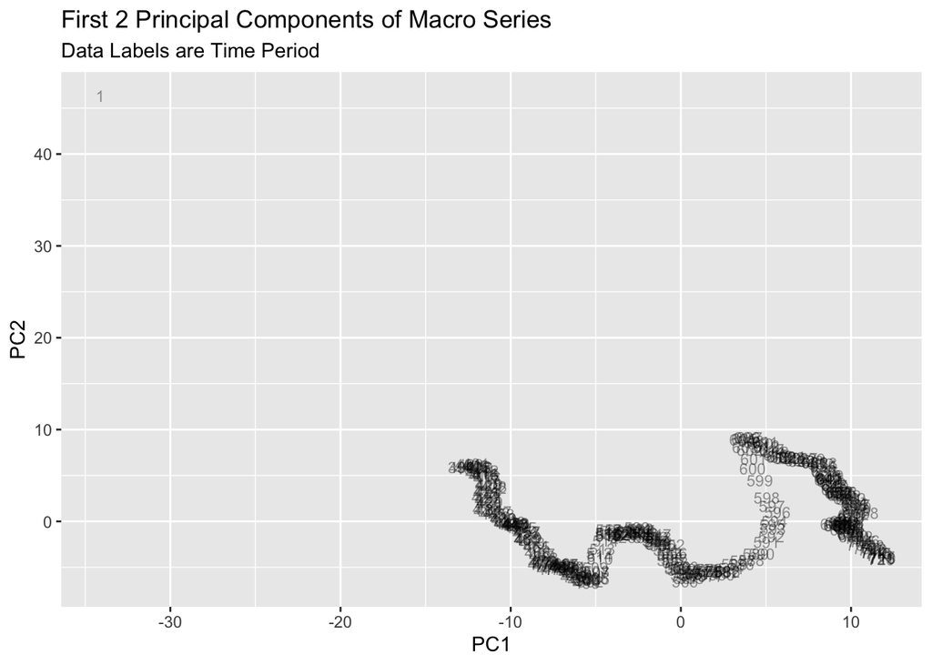

```r
#You can use default biplot(mdPCA) to get a version of this, including arrows displaying loadings, but it is too busy to read
# cf https://stackoverflow.com/questions/6578355/plotting-pca-biplot-with-ggplot2

data <- data.frame(obsnames=row.names(mdPCA$x), mdPCA$x)
plot <- ggplot(data, aes_string(x="PC1", y="PC2")) + geom_text(alpha=.4, size=3, aes(label=obsnames))+
        ggtitle("First 2 Principal Components of Macro Series",subtitle="Data Labels are Time Period")
plot
```

## Alternatives: Nonlinear Methods and Sparsity

- Most common dimensionality reduction approaches and corresponding predictions are linear
  - $X_t$ defined in terms of linear function of unknown components $F_t$
- It is completely possible to allow a **nonlinear** representation instead
  - Can have $X_t\approx T(F_t,\theta)$ for some nonlinear $T()$, with parameters learned from data
- Finding a good nonlinear transformation can be difficult, as not all cases preserve structure of data
- Case allowing for general nonlinearities called “manifold learning”
  - Variety of approaches exist: diffusion maps (`diffusionMap` in R), isomap, LLE, kernel PCA, etc
  - **Autoeencoders** use neural network functions as map: recently most popular method
- All used in similar way to PCA, to extract low-dimensional set of features to use for visualization and prediction
- Alternative approach is to just pick small subset of series: **sparse** representation
  - Problem is that you may not know which series best describe $X_t$ and/or $y_t$
    - More useful if sparsity pattern learned in supervised approach
  - If all series highly correlated, as in macroeconomics, sparse representation may be worse than factor representation at same $d$

## Factor Models: Dynamic Case

- Factor model approach useful for getting current summary of $X_t$
- To leverage this for forecasting, use **Dynamic Factor Model**, which uses past factors to predict future ones
- X still depends on factors, and factors $F_t$ follow vector autoregression
  - $X_t=\Lambda F_t+e_t$, $F_{t}=AF_{t-1}+u_t$
- Format is exactly that of of a state space model, with $d$-dimensional state, $N$ dimensional observations
- If we assume $e_{i,t}\overset{iid}{\sim} N(0,\sigma^2_e)$, $u_{j,t}\overset{iid}{\sim} N(0,\sigma^2_u)$, can estimate and predict using Kalman Filter
  - Estimate like any other state space model, and predict using filtered estimates $\widehat{F}_{T}$ of factors
  - Use likelihood for Bayesian version with priors on coefficients, cf R library `bayesdfa`
- Can allow additional lags of factors in model, or including standard state space components like trends, seasons, etc
- Would it help to predict $X_t$ using lags of $F_{t-j}$, i.e. $X_t=B(L) F_t+e_t$ for some lag polynomial?
  - It turns out, not needed: if lags matter for $X_t$, they show up as extra factors
  - But, in this case, dimension of shocks $u_t$ may be smaller than dimension $d$ of factors, so allow for this in model

## Two Step Estimation of Dynamic Factor Model

- An easier and more robust method exploits fact that $X$ still has factor structure
  - Step 1: Use PCA on $X$ to obtain $\{\widehat{F}_t\}_{t=1}^{T}$ in $X_t=\Lambda F_t+e_t$
  - Step 2: Estimate VAR in $\widehat{F}_T$ to obtain $A$ in $\widehat{F}_{t}=A\widehat{F}_{t-1}+u_t$
- Usefulness of this method is that PCA gives good predictions even if $X_t$ doesn’t have exact factor structure
  - $e_t$ can have some remaining correlations between series even after $\Lambda F_t$ taken out
  - Can also have $e_{i,t}$ autocorrelated, reflecting predictability not captured by $F_t$
- Extra error introduced due to fact that factors estimated, but *if* $N,T$ both large, this is small
- Do need stationarity, weak dependence for good estimates, as usual for ERM
  - Since needed for **all** series in $X_t$, be careful to difference or detrend each before estimation
- In practice, extra robustness often results in better performance than Bayesian estimate based on exact factor structure
- Bayesian approach useful if $T$ or $N$ not super big, so factors estimated imprecisely
  - Also can handle nonstationary factors, if form of nonstationarity specified correctly

## Factor-Augmented Regression

- To predict series $y_{t+h}$ which is not in $X$ using dynamic factors, simply include $\widehat{F}_t$ as predictors
  - Estimate $\widehat{F}_t$ by PCA, which is appropriate in static or dynamic case
- Use predictor class $\mathcal{F}=\{f(\widehat{F},\beta)=\beta_0+\sum_{j=1}^{d}f_j\beta_{j}:\ \beta\in\mathbb{R}^{d+1}\}$ inside ERM or other estimator
- Like standard ERM with minor caveat that predictors no longer given but first estimated using the data
- Properties are similar, in terms of risk: under stationarity, weak dependence, etc, risk converges to oracle risk
- Can also add $\widehat{F}_t$ along with a set of other, carefully chosen predictors in a **Factor Augmented VAR** (FAVAR)
  - Allows using additional idiosyncratic info in small set of series, along with correlated info in others, to predict outcome of interest
- Extremely popular in policy circles
  - Jim Stock, one of developers of Dynamic Factor Model, was head of Council of Economic Advisors
  - FAVAR developed by group including former Fed Chair Ben Bernanke
    - Used to analyze interaction of monetary policy, inflation, and employment, which Fed is mandated to take into account
    - Allows incorporating huge amount of other series used by Fed

```r
## Code to Fit Bayesian factor models
# Run this on your own time, as it is too slow to run each time I compile the file

#library(bayesdfa) #Bayesian Factor Models

# library(fredr) #Data Source
# fredr_set_key("8782f247febb41f291821950cf9118b6") #Key I obtained for this class
#
# serieslist<-c("GS1M","GS3M","GS6M","GS1","GS2","GS3","GS5","GS7","GS10","GS20","GS30")
#
# treasuryyields<-list()
# for (i in 1:length(serieslist)){
#
#   val<-fredr(series=serieslist[i])
#
#   treasuryyields[[i]]<-ts(val$value,frequency=12,names=serieslist[i],names=serieslist[i])
# }

# options(mc.cores = parallel::detectCores()) #Use parallel computing when running MCMC

### Warning: With Data Size this large, following command does not appear feasible on a laptop
## Command works fune on small data sets, but not on this one
## #Fit Bayesian Dynamic Factor Model using "bayesdfa"
## dynfactormodel<- fit_dfa(
##   y = t(finseries), num_trends = 3, zscore = TRUE,
##   iter = 2000, chains = 4, thin = 1
## )

# ## Alternate approach: try 1 factor model of just small set of interest series
# # This is also very slow, but at least feasible. Total estimation takes 76 minutes on a 4-core laptop.
# fins1<-data.frame(currentMD$FEDFUNDS, currentMD$GS1,currentMD$GS5,currentMD$GS10)
# # Bayesian 1 factor model, 4 normalized series, with random walk assumed for factor dynamics
# dynfactormodel<- fit_dfa(
#   y = t(fins1), num_trends = 1, zscore = TRUE,
#   iter = 2000, chains = 4, thin = 1
# )
# #Select a rotation of factors (irrelevant with 1, but this also computes summary stats)
# rt<-rotate_trends(dynfactormodel)
# #Plot factor over time
# plot_trends(rt)
# #Plot predictions for each series
# plot_fitted(dynfactormodel)
# #Plot posterior estimates of factor loadings
# plot_loadings(rt)
```

## Nowcasting

- A common problem when using many data series is that not all are available at the same time
- Some may be at different frequencies: e.g., quarterly, annual, monthly
  - Even within a month, some may come out earlier or later in month,
- Result is that current period information is incomplete, containing some series but not others
- Goal of **Nowcasting** is to use this incomplete info to predict a missing or external series
  - E.g., use monthly releases to predict quarterly GDP
- Good nowcasts can be achieved using slight variant of dynamic factor model
  - $x_{i,t}=\sum_{j=1}^d \lambda_{i,j} f_{j,t}+u_t$ if $i$ observed in period $t$, otherwise it disappears
  - Factors still follow VAR $F_t=AF_{t-1}+e_{t}$
- Kalman filter allows inferring $\widehat{F}_{t}$ even with missing data
  - Get good estimate of current factors with whatever data is available
  - Can “fill in” what a series would have been using current guess of factors plus known factor loadings

## Nowcasting: One Approach

- “2 step procedure” due to Giannone, Reichlin, Small (2008), originators of procedure
1. Estimate parameters of dynamic factor model
   - 1. Estimate $d$ factors $F_t$ from series by PCA on $X_t$
   - 2. Aggregate monthly series up to quarterly data, and estimate loadings of $y_{t}$ on factors by Least Squares
     - $\widehat{\beta}=\underset{\beta}{\arg\min}\sum_{k=1}^{T/3}(y_{k}-\sum_{j=1}^{d}\beta_j\widehat{f}_{j,3k})^2$
   - 3. Estimate VAR in $F_t$, $F_t=AF_{t-1}+e_{t}$ by OLS using PCA factors
2. Predict current factors using Kalman filter and use in forecast
   - 1. Run Kalman filter from dynamic factor model to get predicted factors $\widehat{F}_{t}$ given current observations
   - 2. Predict $\widehat{y}_{k}=\widehat{F}_{t}\widehat{\beta}$
- Apply to set of monthly US economic indicators (1982-2007) from Giannone et. al. for predicting quarterly GDP
  - Implemented in `nowcasting` library
  - Select $d$ by Bai-Ng Criterion, estimate model by above

```r
library(nowcasting)
#Example syntax for nowasting based on quarterly factor model as in Giannone, Reichlin, Small (2011)


# Old Syntax: manually aggregate
# #Use Stock-Watson US GDP and indicators data
# gdp <- month2qtr(x = USGDP$base[,"RGDPGR"])
# # Extract Real GDP Growth from data
# gdp_position <- which(colnames(USGDP$base) == "RGDPGR")
# #Aggregate monthly up to quarterly data
# capture.output(base <- Bpanel(base = USGDP$base[,-gdp_position],trans = USGDP$legend$Transformation[-gdp_position],aggregate = TRUE),file="/dev/null")

#New syntax (automatically aggregates)
data(USGDP)
gdp_position <- which(colnames(USGDP$base) == "RGDPGR")
base <- Bpanel(base = USGDP$base[,-gdp_position],
               trans = USGDP$legend$Transformation[-gdp_position],
               aggregate = TRUE)
```

```
## [1] "AVGWKLYCL" "CPOUT"     "M3"
```

```r
usdata <- cbind(USGDP$base[,"RGDPGR"], base)
colnames(usdata) <- c("RGDPGR", colnames(base))
frequency <- c(4, rep(12, ncol(usdata) -1))
```

## Diagnostics: Find order of factor model by Bai-Ng Criterion

```r
#Diagnostics 1: Select number of Factors by Bai-Ng Information Criterion
factorselect<-ICfactors(base)
```

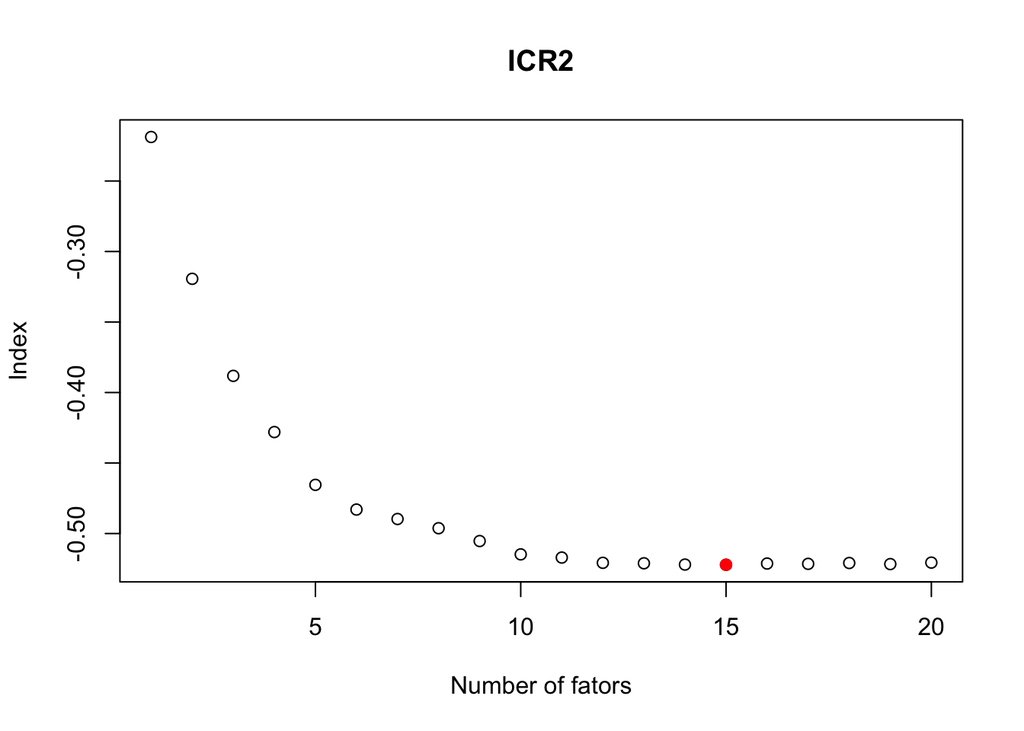

```r
#Diagnostics 2: Select number of lags and shocks by another info criterion
shockselect<-ICshocks(base,r=factorselect$r_star)
```

## Results: Nowcast

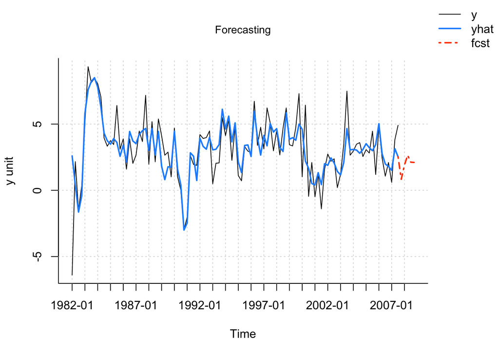

```r
#Run 2 step nowcasting, with optimal # of factors, lags, and error terms

#Old Syntax
#now2sq <- nowcast(y = gdp, x = base, r = factorselect$r_star, p = shockselect$p, q = shockselect$q_star, method = '2sq')

#New Syntax
now2s <- nowcast(formula = RGDPGR ~ ., data = usdata, r = factorselect$r_star, p = shockselect$p, q = shockselect$q_star,
          method = '2s', frequency = frequency)

#Plot results
nowcast.plot(now2s,type="fcst")
```

## Results: Factor Estimates

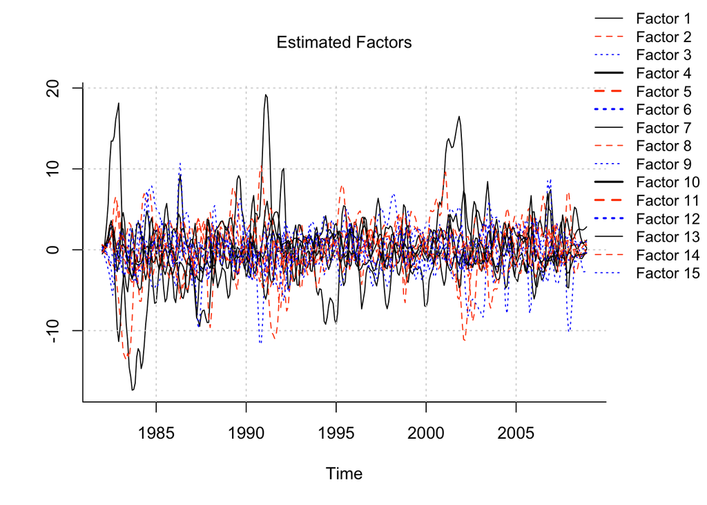

```r
#Plot results
nowcast.plot(now2s,type="factors")
```

```r
#Additional Displays, Not Shown

##Fraction of variance Explained by each factor
#nowcast.plot(now2s,type="eigenvalues")
## Display factor loadings of each series on Factor 1
#nowcast.plot(now2s,type="eigenvectors")
```

## Application: Financial Times Nowcast

- Gavyn Davies at Financial Times reports nowcasts and forecasts global economic growth each month
  - Uses Bayesian Dynamic Factor Model due to Juan Antolin-Diaz et al at Fulcrum Asset Management
- Uses releases from all major economies to predict global and region-specific factors
- Bayesian state space model with unit roots, seasonality, heavy tailed errors and time-varying variance
  - Additional features improve uncertainty forecasts, account for correlation properties of data

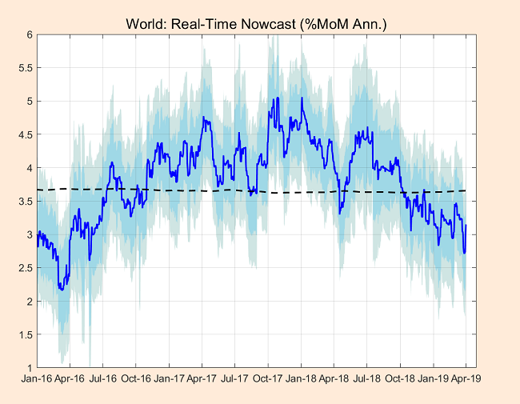

## Conclusions

- Many economic forecasting problems have more predictors available than can be incorporated in existing methods
- Simple solution is to reduce dimensionality of data by producing small set of combinations that contain most info
- Factor models use linear combinations, and can be estimated by Principal Components Analysis
  - Don’t take separate factors themselves as anything meaningful: only their combinations are determined by data
- Forecast using this information by adding factors as predictors or treating as a latent state
  - Dynamic Factor Model is special case of a linear state space model with fewer states than observables
- Factor models are currently dominant approach in applied macroeconomic forecasting
- Also useful for combining data at *mixed frequency* to “nowcast” series not yet updated

## References

- Jushan Bai and Serena Ng (2002) “Determining the Number of Factors in Approximate Factor Models” *Econometrica* Volume 70, No.1, pp 191-221.
- Ben Bernanke, Jean Boivin, Piotr Eliasz (2005) “Measuring the Effects of Monetary Policy: A Factor-Augmented Vector Autoregressive (FAVAR) Approach” *The Quarterly Journal of Economics*, Volume 120, Issue 1, February, pp 387–422.
  - Introduced FAVARs
- Gavyn Davies “Global economy may still defy the pessimists this year” Financial Times, April 7, 2019
  - Access nowcasts without FT subscription via [Fulcrum Asset Management](https://www.fulcrumasset.com/uk-iach/blog/)
- Domenico Giannone, Lucrezia Reichlin, David Small (2008) “Nowcasting: The real-time informational content of macroeconomic data” *Journal of Monetary Economics* 55 pp 665-676.
- Michael McCracken and Serena Ng (2014) “FRED-MD: A Monthly Database for Macroeconomic Research”
- James Stock and Mark Watson (2002) “Forecasting Using Principal Components From a Large Number of Predictors” *Journal of the American Statistical Association* December, Vol 97, No 460
  - Describes factor-augmented regression forecasting